## Model gene expression data with a generalized linear model

Xulong Wang (xulong.wang@jax.org)

```r
rm(list = ls())
setwd("~/Dropbox/GitHub/Ad")
source("function.R")
load("./data/brain2014.rdt")
dt <- brain.tpm
# load("./data/retina2014.rdt")
# dt <- retina.tpm
```

##### This is the distribution of gene expression values for all genes in all 2014 samples in log2-transformed-TPM unit.

```r
dim(dt)
```

```
## [1] 13392    59
```

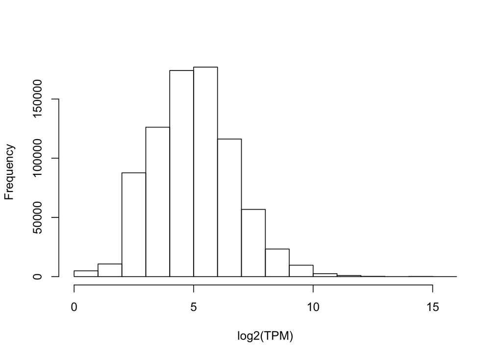

```r
hist(c(as.matrix(dt)), main = "", xlab = "log2(TPM)")
```

##### We kept genes who fit two criterias:

1. Maximal expression must be bigger than 0.25 quantile of the complete datasets
2. Expression value must be bigger than 0 in at least 1/10 of the samples.

```r
cutoff <- quantile(c(as.matrix(dt)), 0.25)  # TPM level
dt <- dt[apply(dt, 1, function(x) max(x) > cutoff), ]
dt <- dt[apply(dt, 1, function(x) sum(x > 0) > round(ncol(dt) / 10)), ]
dim(dt)
```

```
## [1] 10843    59
```

##### Each gene’s expression values were modeled with a generalized linear model (GLM) by 4 predictors: age, group, batch, and age group interaction.

```r
age <- factor(gsub("^.*(2m|4m|5m|6m).*", "\\1", colnames(dt)), levels = c("2m", "4m", "5m", "6m"))
group <- factor(gsub("^.*(WT|APP).*", "\\1", colnames(dt)), levels = c("WT", "APP"))
batch <- factor(gsub("^.*(2014|mouse).*", "\\1", colnames(dt)), levels = c("2014", "mouse"))
uid <- paste(age, group, sep = "_")
conditions <- c("2m_WT", "2m_APP", "4m_WT", "4m_APP", "5m_WT", "5m_APP", "6m_WT", "6m_APP")
glm.dt <- as.matrix(dt)
glm.fit <- lapply(1:nrow(glm.dt), function (x) summary(lm(glm.dt[x, ] ~ age + group + batch + age * group)))
names(glm.fit) <- rownames(glm.dt)
colnames(dt)
```

```
##  [1] "WT6m1484.2014"     "WT5m1551.2014"     "APP5m1558.2014"
##  [4] "WT5m1561.2014"     "WT5m1562.2014"     "WT5m1621.2014"
##  [7] "APP5m1623.2014"    "APP5m1633.2014"    "WT5m1634.2014"
## [10] "APP5m1636.2014"    "APP5m1647.2014"    "APP5m1648.2014"
## [13] "WT6m1651.2014"     "WT6m1652.2014"     "WT6m1653.2014"
## [16] "WT6m1654.2014"     "APP6m1684.2014"    "WT4m1708.2014"
## [19] "APP5m1738.2014"    "APP4m1744.2014"    "WT4m1745.2014"
## [22] "WT4m1746.2014"     "WT4m1747.2014"     "WT4m1824.2014"
## [25] "WT4m1876.2014"     "WT4m1877.2014"     "WT6m1883.2014"
## [28] "WT6m1884.2014"     "WT5m2628.2014"     "WT5m2630.2014"
## [31] "WT5m2632.2014"     "APP5m2633.2014"    "WT5m2634.2014"
## [34] "APP5m2735.2014"    "WT5m2736.2014"     "WT5m2738.2014"
## [37] "APP5m2751.2014"    "WT5m2752.2014"     "WT5m2753.2014"
## [40] "WT2m3234.2014"     "WT2m3235.2014"     "WT2m3239.2014"
## [43] "WT2m3269.2014"     "WT2m3272.2014"     "APP2m3310.2014"
## [46] "APP2m3316.2014"    "APP2m3317.2014"    "mouse_3346_6m_APP"
## [49] "mouse_3351_6m_APP" "mouse_3440_6m_APP" "mouse_3465_4m_WT"
## [52] "mouse_3466_4m_WT"  "mouse_3596_2m_APP" "mouse_3624_4m_APP"
## [55] "mouse_3662_4m_APP" "mouse_3670_2m_APP" "mouse_3681_4m_APP"
## [58] "mouse_3700_4m_APP" "mouse_6585_6m_APP"
```

```r
age
```

```
##  [1] 6m 5m 5m 5m 5m 5m 5m 5m 5m 5m 5m 5m 6m 6m 6m 6m 6m 4m 5m 4m 4m 4m 4m
## [24] 4m 4m 4m 6m 6m 5m 5m 5m 5m 5m 5m 5m 5m 5m 5m 5m 2m 2m 2m 2m 2m 2m 2m
## [47] 2m 6m 6m 6m 4m 4m 2m 4m 4m 2m 4m 4m 6m
## Levels: 2m 4m 5m 6m
```

```r
group
```

```
##  [1] WT  WT  APP WT  WT  WT  APP APP WT  APP APP APP WT  WT  WT  WT  APP
## [18] WT  APP APP WT  WT  WT  WT  WT  WT  WT  WT  WT  WT  WT  APP WT  APP
## [35] WT  WT  APP WT  WT  WT  WT  WT  WT  WT  APP APP APP APP APP APP WT
## [52] WT  APP APP APP APP APP APP APP
## Levels: WT APP
```

```r
batch
```

```
##  [1] 2014  2014  2014  2014  2014  2014  2014  2014  2014  2014  2014
## [12] 2014  2014  2014  2014  2014  2014  2014  2014  2014  2014  2014
## [23] 2014  2014  2014  2014  2014  2014  2014  2014  2014  2014  2014
## [34] 2014  2014  2014  2014  2014  2014  2014  2014  2014  2014  2014
## [45] 2014  2014  2014  mouse mouse mouse mouse mouse mouse mouse mouse
## [56] mouse mouse mouse mouse
## Levels: 2014 mouse
```

##### This shows what we get from the GLM, take App for example

```r
glm.fit[["App"]]
```

```
##
## Call:
## lm(formula = glm.dt[x, ] ~ age + group + batch + age * group)
##
## Residuals:
##       Min        1Q    Median        3Q       Max
## -0.103947 -0.026951 -0.000426  0.031064  0.085122
##
## Coefficients:
##                Estimate Std. Error t value Pr(>|t|)
## (Intercept)    10.49803    0.01861 564.206   <2e-16 ***
## age4m          -0.01066    0.02363  -0.451   0.6539
## age5m          -0.03711    0.02189  -1.695   0.0963 .
## age6m          -0.06245    0.02436  -2.563   0.0134 *
## groupAPP        0.96882    0.02750  35.235   <2e-16 ***
## batchmouse     -0.04023    0.01994  -2.018   0.0490 *
## age4m:groupAPP  0.04023    0.03526   1.141   0.2593
## age5m:groupAPP  0.05078    0.03259   1.558   0.1256
## age6m:groupAPP  0.02422    0.03674   0.659   0.5127
## ---
## Signif. codes:  0 '***' 0.001 '**' 0.01 '*' 0.05 '.' 0.1 ' ' 1
##
## Residual standard error: 0.04161 on 50 degrees of freedom
## Multiple R-squared:  0.9939, Adjusted R-squared:  0.9929
## F-statistic:  1020 on 8 and 50 DF,  p-value: < 2.2e-16
```

##### We took off each gene’s batch effect as estimated by the GLM from its raw expression value. The batch-corrected expression values were used in the downstream pair-wise comparisons.

```r
dt.bc <- dt
for (i in 1:nrow(dt.bc))
  dt.bc[i, ] <- dt[i, ] - glm.fit[[i]]$coefficients["batchmouse", "Estimate"] * (as.numeric(batch) - 1)
```

##### R2 and F-test p-value from the GLM define how well each gene’s expression across the samples could be predicted from the model’s predictors, which are age, group, batch, and age group interaction. Small p-value and big R2 suggest good fit.

##### We searched age- and app-related genes by two criterias with different levels of stringencies on p-value and R2. The more stringent criteria was applied in this document.

```r
r2 <- sapply(glm.fit, function (x) x$r.squared)
fval <- sapply(glm.fit, function (x) x$fstatistic)
pval <- apply(fval, 2, function (x) pf(x[1], x[2], x[3], lower.tail = F))
qval <- p.adjust(pval, method = "fdr")

fit.qr <- glm.fit[qval < 0.05 & r2 > 0.5]
geneId <- names(fit.qr)
length(fit.qr)
```

```
## [1] 448
```

##### In each gene’s GLM return, the “Estimate” column represents each predictor’s effect size; the “Pr(>|t|)” column represents the corresponding significance. We constructed a matrix of each gene’s estimates on each predictor, and another matrix of the corresponding significance values.

```r
fit.qr[["App"]]$coefficients
```

```
##                   Estimate Std. Error     t value     Pr(>|t|)
## (Intercept)    10.49802829 0.01860672 564.2062503 8.932371e-97
## age4m          -0.01065783 0.02362574  -0.4511110 6.538600e-01
## age5m          -0.03710797 0.02189447  -1.6948560 9.632304e-02
## age6m          -0.06244793 0.02436192  -2.5633422 1.342184e-02
## groupAPP        0.96882037 0.02749563  35.2354293 5.690012e-37
## batchmouse     -0.04023277 0.01993577  -2.0181194 4.896016e-02
## age4m:groupAPP  0.04023281 0.03526372   1.1409121 2.593418e-01
## age5m:groupAPP  0.05077686 0.03259252   1.5579297 1.255577e-01
## age6m:groupAPP  0.02422343 0.03673571   0.6593974 5.126664e-01
```

```r
fit.est <- lapply(fit.qr, function (x) x$coefficients[, "Estimate"])
fit.est <- do.call(rbind, fit.est)
tail(fit.est)
```

```
##        (Intercept)       age4m       age5m       age6m    groupAPP
## Zfp318    5.089064  0.01086858 -0.08927259 -0.07542847  0.14396268
## Zfp622    4.788541  0.09089091  0.13319907  0.19968900  0.03993155
## Zfp652    4.458444  0.03255939 -0.13595977 -0.13326616  0.05843654
## Zfp930    4.266428 -0.11920216 -0.19007692 -0.14945906 -0.04830627
## Zfp941    4.591074  0.11126461  0.14292839  0.20708249  0.25283184
## Znhit1    5.990962  0.10459855  0.08484321  0.11911151 -0.01957310
##           batchmouse age4m:groupAPP age5m:groupAPP age6m:groupAPP
## Zfp318 -0.0004605902    -0.02684971   -0.119516525    -0.05992309
## Zfp622 -0.1278743105    -0.02980216   -0.070642931    -0.08492906
## Zfp652 -0.1273035960     0.01330191   -0.006054647     0.06912644
## Zfp930  0.0091032983     0.13093970   -0.069695426     0.13651753
## Zfp941 -0.0318969240     0.06775115   -0.202977395    -0.20578264
## Znhit1 -0.1891417053    -0.11922833   -0.032852587    -0.11684318
```

```r
fit.pval <- lapply(fit.qr, function (x) x$coefficients[, "Pr(>|t|)"])
fit.pval <- do.call(rbind, fit.pval)
tail(fit.pval)
```

```
##         (Intercept)       age4m        age5m        age6m     groupAPP
## Zfp318 1.969983e-66 0.815666863 4.294427e-02 1.210372e-01 0.0102766823
## Zfp622 1.275410e-72 0.007821868 6.024812e-05 3.080232e-07 0.3005305320
## Zfp652 2.308218e-66 0.428170577 7.311740e-04 2.596548e-03 0.2237425760
## Zfp930 1.398406e-57 0.047033914 9.768715e-04 1.671552e-02 0.4815800286
## Zfp941 7.178858e-62 0.036078147 4.369219e-03 2.986115e-04 0.0001075915
## Znhit1 6.231957e-68 0.045301539 7.835749e-02 2.771817e-02 0.7426779880
##          batchmouse age4m:groupAPP age5m:groupAPP age6m:groupAPP
## Zfp318 9.906562e-01      0.6997515    0.067616480     0.40993491
## Zfp622 2.717113e-05      0.5454320    0.124761605     0.10209979
## Zfp652 5.347451e-04      0.8278140    0.914681214     0.28062153
## Zfp930 8.545289e-01      0.1402639    0.392237461     0.13994538
## Zfp941 4.676926e-01      0.3837253    0.006359872     0.01346123
## Znhit1 5.682137e-05      0.1231890    0.642200570     0.14646632
```

##### To identify each gene’s critical predictors, we binarized the estimate and significance matrices by hard cutoffs. Less stringent cutoffs were applied in a separate analysis.

```r
logit <- apply(fit.pval, 2, function (x) x < 0.05) & apply(fit.est, 2, function (x) abs(x) > 0.2)
tail(logit)
```

```
##        (Intercept) age4m age5m age6m groupAPP batchmouse age4m:groupAPP
## Zfp318        TRUE FALSE FALSE FALSE    FALSE      FALSE          FALSE
## Zfp622        TRUE FALSE FALSE FALSE    FALSE      FALSE          FALSE
## Zfp652        TRUE FALSE FALSE FALSE    FALSE      FALSE          FALSE
## Zfp930        TRUE FALSE FALSE FALSE    FALSE      FALSE          FALSE
## Zfp941        TRUE FALSE FALSE  TRUE     TRUE      FALSE          FALSE
## Znhit1        TRUE FALSE FALSE FALSE    FALSE      FALSE          FALSE
##        age5m:groupAPP age6m:groupAPP
## Zfp318          FALSE          FALSE
## Zfp622          FALSE          FALSE
## Zfp652          FALSE          FALSE
## Zfp930          FALSE          FALSE
## Zfp941           TRUE           TRUE
## Znhit1          FALSE          FALSE
```

##### The APP- and age-related genes were identified as those who passed the cutoff in at least one of the APP- and age-related predictors, respectively.

```r
geneId.age <- geneId[as.logical(rowSums(logit[, grep("age", colnames(fit.pval))]))]
geneId.age
```

```
##   [1] "1700047I17Rik2" "2310036O22Rik"  "2900079G21Rik"  "9430020K01Rik"
##   [5] "A030009H04Rik"  "AC182748.1"     "Actn1"          "Akap5"
##   [9] "Aldh9a1"        "Ank3"           "Ankrd17"        "Ankrd52"
##  [13] "Ap2b1"          "Apod"           "Apoe"           "Arhgef7"
##  [17] "Arid1a"         "Asap1"          "Asl"            "Ass1"
##  [21] "Atp2a2"         "Atp2b2"         "C1qa"           "C1qc"
##  [25] "C1qtnf4"        "C4b"            "Cacna1e"        "Camk4"
##  [29] "Camsap1"        "Car4"           "Cbx7"           "Ccdc124"
##  [33] "Ccdc85b"        "Ccnd2"          "Cdkn2aipnl"     "Chchd10"
##  [37] "Cit"            "Cldn11"         "Col4a1"         "Coprs"
##  [41] "Cox17"          "Crebbp"         "Cst3"           "Ctss"
##  [45] "Ctsz"           "Cyb5r1"         "D430041D05Rik"  "Dio2"
##  [49] "Dnajb11"        "Dnmt3a"         "Dpcd"           "Dpysl3"
##  [53] "Ech1"           "Erc1"           "Fam213a"        "Fry"
##  [57] "Gas7"           "Gatm"           "Gm10231"        "Gm12054"
```

[output cut: 29 more lines]

```r
geneId.app <- geneId[as.logical(rowSums(logit[, grep("APP", colnames(fit.pval))]))]
geneId.app
```

```
##  [1] "1700047I17Rik2" "2310036O22Rik"  "2900079G21Rik"  "App"
##  [5] "Arpp21"         "Asl"            "Cacna1e"        "Ccdc124"
##  [9] "Ccdc85b"        "Col4a1"         "Cox17"          "Crebbp"
## [13] "Dio2"           "Dnajb11"        "Ech1"           "Gm17131"
## [17] "Gm20390"        "Gm21962"        "Gnat1"          "Grid2ip"
## [21] "Grin2a"         "Gtpbp6"         "H2afj"          "Htr2a"
## [25] "Lamr1-ps1"      "Lsm4"           "Manf"           "Mical3"
## [29] "Mirg"           "Mpeg1"          "Mpzl1"          "Mrpl27"
## [33] "Myh9"           "Ndufa2"         "Ndufaf2"        "Ndufb2"
## [37] "Ndufc2"         "Nsdhl"          "Ntrk3"          "Piga"
## [41] "Plxna3"         "Plxna4"         "Pmm1"           "Prnp"
## [45] "Psen1"          "Rho"            "Rpl35"          "Rps19"
## [49] "Rps21"          "Slc8a1"         "Smdt1"          "Spint2"
## [53] "Stard4"         "Syvn1"          "Tef"            "Tmem242"
## [57] "Tnfrsf22"       "Tomm6"          "Uba52"          "Vps37d"
## [61] "Zfp941"
```

##### GO and KEGG enrichment analysis was applied on the APP- and age-related genes

```r
gk.app <- myGK(geneId.app)
head(gk.app$BP[, c("Term", "Pvalue")])
```

```
##                                                   Term       Pvalue
## 1                                             behavior 2.242748e-06
## 2 smooth endoplasmic reticulum calcium ion homeostasis 5.043795e-06
## 3                                   learning or memory 6.695343e-06
## 4                                            cognition 1.293660e-05
## 5                        cellular chemical homeostasis 1.693747e-05
## 6                  calcium ion transmembrane transport 2.278303e-05
```

```r
head(gk.app$MF[, c("Term", "Pvalue")])
```

```
##                                                                                  Term
## 1                                            NADH dehydrogenase (ubiquinone) activity
## 2                                               NADH dehydrogenase (quinone) activity
## 3                                                         NADH dehydrogenase activity
## 4 oxidoreductase activity, acting on NAD(P)H, quinone or similar compound as acceptor
## 5                                      calcium ion transmembrane transporter activity
## 6                                                        semaphorin receptor activity
##         Pvalue
## 1 2.943154e-05
## 2 2.943154e-05
## 3 3.305628e-05
## 4 7.951044e-05
## 5 1.469447e-04
## 6 2.343620e-04
```

```r
head(gk.app$CC[, c("Term", "Pvalue")])
```

```
##                          Term       Pvalue
## 1          mitochondrial part 2.142711e-05
## 2 mitochondrial membrane part 2.271024e-05
## 3      mitochondrial membrane 2.303755e-05
## 4               mitochondrion 2.829563e-05
## 5 somatodendritic compartment 2.888908e-05
## 6      macromolecular complex 3.410685e-05
```

```r
head(gk.app$KEGG[, c("Term", "Pvalue")])
```

```
##                        Term       Pvalue
## 1       Alzheimer's disease 0.0002631084
## 2                  Ribosome 0.0028387608
## 3 Oxidative phosphorylation 0.0054019260
## 4         Phototransduction 0.0095038471
```

```r
gk.age <- myGK(geneId.age)
head(gk.age$BP[, c("Term", "Pvalue")])
```

```
##                                Term       Pvalue
## 1  regulation of biological quality 6.357890e-09
## 2                 metabolic process 1.828872e-07
## 3 single-organism metabolic process 3.109175e-07
## 4                  cellular process 5.505756e-07
## 5        nervous system development 6.096050e-07
## 6                      neurogenesis 6.278347e-07
```

```r
head(gk.age$MF[, c("Term", "Pvalue")])
```

```
##                                 Term       Pvalue
## 1                    protein binding 6.943203e-09
## 2 structural constituent of ribosome 1.411831e-08
## 3       structural molecule activity 1.765702e-06
## 4                 calmodulin binding 9.106290e-06
## 5                            binding 1.080357e-05
## 6       semaphorin receptor activity 3.471588e-05
```

```r
head(gk.age$CC[, c("Term", "Pvalue")])
```

```
##                          Term       Pvalue
## 1          cytosolic ribosome 1.578039e-11
## 2                    ribosome 1.042983e-09
## 3           ribosomal subunit 1.575543e-09
## 4              cytosolic part 3.941771e-09
## 5 somatodendritic compartment 5.730363e-09
## 6                   cytoplasm 9.395527e-09
```

```r
head(gk.age$KEGG[, c("Term", "Pvalue")])
```

```
##                              Term       Pvalue
## 1                        Ribosome 1.311303e-08
## 2       Calcium signaling pathway 1.394302e-03
## 3 Arginine and proline metabolism 4.113916e-03
## 4    Systemic lupus erythematosus 9.474179e-03
## 5          Long-term potentiation 9.798741e-03
```

##### This gives the overlap between the age- and app-genes.

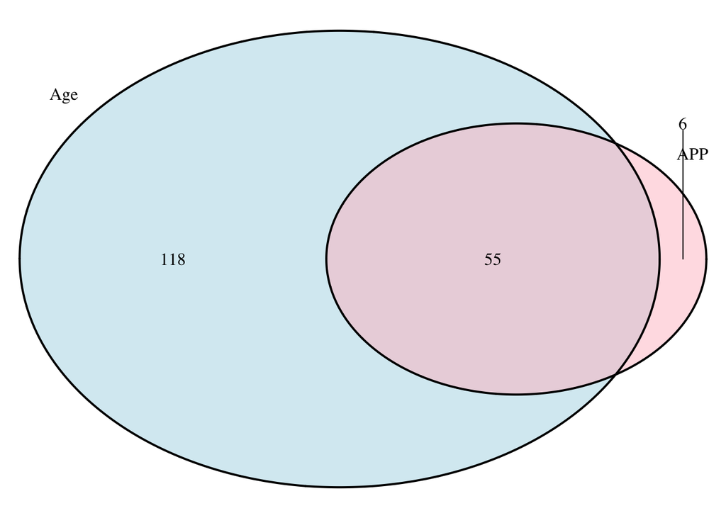

```
## (polygon[GRID.polygon.11], polygon[GRID.polygon.12], polygon[GRID.polygon.13], polygon[GRID.polygon.14], text[GRID.text.15], text[GRID.text.16], lines[GRID.lines.17], text[GRID.text.18], text[GRID.text.19], text[GRID.text.20])
```

```r
grid.newpage()
draw.pairwise.venn(length(geneId.age), length(geneId.app), length(intersect(geneId.age, geneId.app)),
                   category = c("Age", "APP"), fill = c("light blue", "pink"))
```

##### To classify the APP-related genes in more detail, we collapsed the binarized matrix gene by gene and grouped genes from the unique collapsed patterns. We will repeat the same procedure for the age-related genes.

```r
profile <- logit[geneId.app, grep("APP", colnames(logit))]
# profile <- logit[geneId.age, grep("age", colnames(logit))]
tail(profile)
```

```
##          groupAPP age4m:groupAPP age5m:groupAPP age6m:groupAPP
## Tmem242     FALSE          FALSE          FALSE           TRUE
## Tnfrsf22    FALSE          FALSE          FALSE           TRUE
## Tomm6       FALSE          FALSE          FALSE           TRUE
## Uba52       FALSE          FALSE          FALSE           TRUE
## Vps37d       TRUE          FALSE           TRUE           TRUE
## Zfp941       TRUE          FALSE           TRUE           TRUE
```

```r
profile.str <- apply(profile, 1, function (x) paste(x, collapse = "-"))
tail(profile.str)
```

```
##                  Tmem242                 Tnfrsf22                    Tomm6
## "FALSE-FALSE-FALSE-TRUE" "FALSE-FALSE-FALSE-TRUE" "FALSE-FALSE-FALSE-TRUE"
##                    Uba52                   Vps37d                   Zfp941
## "FALSE-FALSE-FALSE-TRUE"   "TRUE-FALSE-TRUE-TRUE"   "TRUE-FALSE-TRUE-TRUE"
```

```r
profile.table <- sort(table(profile.str))
profile.Id <- names(profile.table)
profile.Id
```

```
##  [1] "FALSE-TRUE-TRUE-FALSE"  "TRUE-FALSE-FALSE-TRUE"
##  [3] "TRUE-TRUE-FALSE-FALSE"  "FALSE-FALSE-TRUE-TRUE"
##  [5] "FALSE-TRUE-FALSE-TRUE"  "TRUE-FALSE-TRUE-FALSE"
##  [7] "FALSE-FALSE-TRUE-FALSE" "TRUE-FALSE-TRUE-TRUE"
##  [9] "TRUE-FALSE-FALSE-FALSE" "FALSE-FALSE-FALSE-TRUE"
```

##### Genes in each group

```r
geneId.profile <- list()
for (idx in profile.Id)
  geneId.profile[[idx]] <- geneId.app[profile.str == idx]
# geneId.profile[[idx]] <- geneId.age[profile.str == idx]
geneId.profile
```

```
## $`FALSE-TRUE-TRUE-FALSE`
## [1] "2900079G21Rik"
##
## $`TRUE-FALSE-FALSE-TRUE`
## [1] "Asl"
##
## $`TRUE-TRUE-FALSE-FALSE`
## [1] "Piga"
##
## $`FALSE-FALSE-TRUE-TRUE`
## [1] "Ccdc124" "Grin2a"
##
## $`FALSE-TRUE-FALSE-TRUE`
## [1] "2310036O22Rik" "Gtpbp6"
##
## $`TRUE-FALSE-TRUE-FALSE`
## [1] "Dnajb11" "Tef"
##
## $`FALSE-FALSE-TRUE-FALSE`
## [1] "Htr2a"   "Mpzl1"   "Ndufaf2" "Rpl35"   "Syvn1"
##
## $`TRUE-FALSE-TRUE-TRUE`
## [1] "Manf"   "Spint2" "Stard4" "Vps37d" "Zfp941"
##
## $`TRUE-FALSE-FALSE-FALSE`
## [1] "App"       "Arpp21"    "Col4a1"    "Dio2"      "Lamr1-ps1" "Nsdhl"
## [7] "Prnp"      "Psen1"
##
## $`FALSE-FALSE-FALSE-TRUE`
##  [1] "1700047I17Rik2" "Cacna1e"        "Ccdc85b"        "Cox17"
##  [5] "Crebbp"         "Ech1"           "Gm17131"        "Gm20390"
##  [9] "Gm21962"        "Gnat1"          "Grid2ip"        "H2afj"
## [13] "Lsm4"           "Mical3"         "Mirg"           "Mpeg1"
## [17] "Mrpl27"         "Myh9"           "Ndufa2"         "Ndufb2"
## [21] "Ndufc2"         "Ntrk3"          "Plxna3"         "Plxna4"
## [25] "Pmm1"           "Rho"            "Rps19"          "Rps21"
## [29] "Slc8a1"         "Smdt1"          "Tmem242"        "Tnfrsf22"
## [33] "Tomm6"          "Uba52"
```

##### A tile plot on the groups with each group’s gene numbers

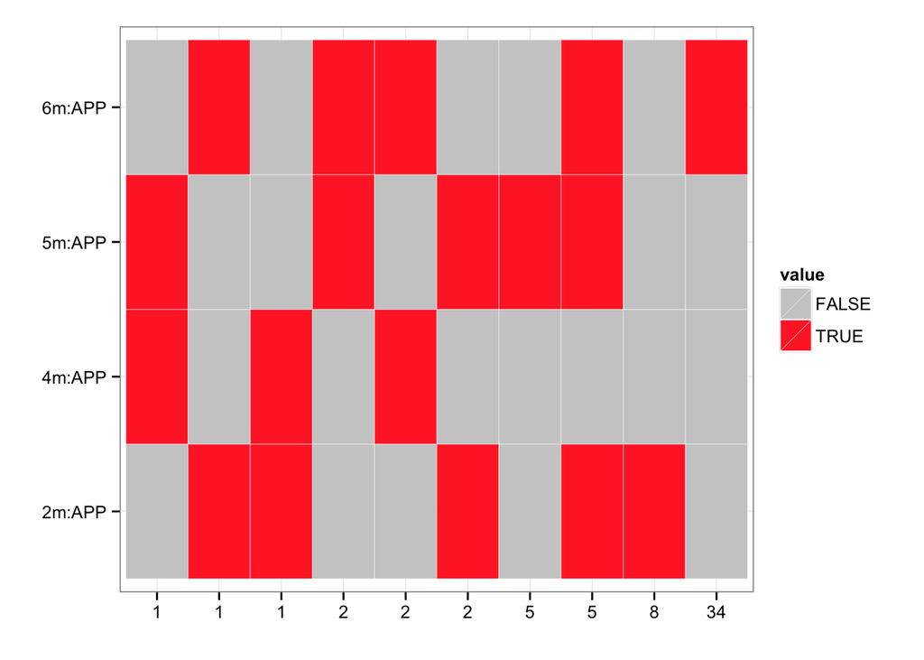

```r
tile.dt <- NULL
for (i in 1:length(profile.Id))
  tile.dt <- rbind(tile.dt, as.logical(unlist(strsplit(profile.Id[i], "-"))))
tile.dt <- data.frame(value = c(tile.dt),
  profile = factor(rep(profile.Id, ncol(tile.dt)), levels = profile.Id),
  group = factor(rep(colnames(profile), each = nrow(tile.dt)), levels = colnames(profile)))

ggplot(tile.dt, aes(x = group, y = profile, fill = value)) + geom_tile(colour = "white") +
  theme_bw() + xlab("") + ylab("") + coord_flip() +
  scale_x_discrete(labels = c("2m:APP", "4m:APP", "5m:APP", "6m:APP")) +
# scale_x_discrete(labels = c("4m:WT", "5m:WT", "6m:WT", "4m:APP", "5m:APP", "6m:APP")) +
  scale_y_discrete(labels = profile.table) +
  scale_fill_manual(values = c("grey80", "firebrick1"))
```

##### We repeated the same procedure to classify age-related genes in different groups.

```r
# profile <- logit[geneId.app, grep("APP", colnames(logit))]
profile <- logit[geneId.age, grep("age", colnames(logit))]
tail(profile)
```

```
##         age4m age5m age6m age4m:groupAPP age5m:groupAPP age6m:groupAPP
## Uba52   FALSE  TRUE  TRUE          FALSE          FALSE           TRUE
## Vmn1r58 FALSE  TRUE  TRUE          FALSE          FALSE          FALSE
## Vps37d   TRUE  TRUE  TRUE          FALSE           TRUE           TRUE
## Vstm2l  FALSE  TRUE  TRUE          FALSE          FALSE          FALSE
## Zdhhc9  FALSE FALSE  TRUE          FALSE          FALSE          FALSE
## Zfp941  FALSE FALSE  TRUE          FALSE           TRUE           TRUE
```

```r
profile.str <- apply(profile, 1, function (x) paste(x, collapse = "-"))
tail(profile.str)
```

```
##                                Uba52                              Vmn1r58
##   "FALSE-TRUE-TRUE-FALSE-FALSE-TRUE"  "FALSE-TRUE-TRUE-FALSE-FALSE-FALSE"
##                               Vps37d                               Vstm2l
##     "TRUE-TRUE-TRUE-FALSE-TRUE-TRUE"  "FALSE-TRUE-TRUE-FALSE-FALSE-FALSE"
##                               Zdhhc9                               Zfp941
## "FALSE-FALSE-TRUE-FALSE-FALSE-FALSE"   "FALSE-FALSE-TRUE-FALSE-TRUE-TRUE"
```

```r
profile.table <- sort(table(profile.str))
profile.Id <- names(profile.table)
profile.Id
```

```
##  [1] "FALSE-FALSE-FALSE-FALSE-TRUE-TRUE"
##  [2] "FALSE-FALSE-FALSE-TRUE-FALSE-FALSE"
##  [3] "FALSE-FALSE-FALSE-TRUE-TRUE-FALSE"
##  [4] "FALSE-FALSE-TRUE-TRUE-FALSE-TRUE"
##  [5] "FALSE-TRUE-TRUE-FALSE-TRUE-TRUE"
##  [6] "FALSE-TRUE-TRUE-TRUE-FALSE-TRUE"
##  [7] "TRUE-FALSE-FALSE-FALSE-FALSE-FALSE"
##  [8] "FALSE-FALSE-FALSE-FALSE-TRUE-FALSE"
##  [9] "FALSE-FALSE-TRUE-FALSE-TRUE-TRUE"
## [10] "FALSE-TRUE-FALSE-FALSE-FALSE-FALSE"
## [11] "TRUE-TRUE-TRUE-FALSE-TRUE-FALSE"
## [12] "FALSE-TRUE-TRUE-FALSE-TRUE-FALSE"
## [13] "TRUE-TRUE-TRUE-FALSE-TRUE-TRUE"
## [14] "FALSE-FALSE-FALSE-FALSE-FALSE-TRUE"
## [15] "FALSE-FALSE-TRUE-FALSE-FALSE-TRUE"
## [16] "TRUE-TRUE-TRUE-FALSE-FALSE-FALSE"
## [17] "FALSE-TRUE-TRUE-FALSE-FALSE-TRUE"
## [18] "FALSE-FALSE-TRUE-FALSE-FALSE-FALSE"
## [19] "FALSE-TRUE-TRUE-FALSE-FALSE-FALSE"
```

##### Genes in each group

```r
geneId.profile <- list()
for (idx in profile.Id)
# geneId.profile[[idx]] <- geneId.app[profile.str == idx]
  geneId.profile[[idx]] <- geneId.age[profile.str == idx]
geneId.profile
```

```
## $`FALSE-FALSE-FALSE-FALSE-TRUE-TRUE`
## [1] "Ccdc124"
##
## $`FALSE-FALSE-FALSE-TRUE-FALSE-FALSE`
## [1] "Piga"
##
## $`FALSE-FALSE-FALSE-TRUE-TRUE-FALSE`
## [1] "2900079G21Rik"
##
## $`FALSE-FALSE-TRUE-TRUE-FALSE-TRUE`
## [1] "Gtpbp6"
##
## $`FALSE-TRUE-TRUE-FALSE-TRUE-TRUE`
## [1] "Grin2a"
##
## $`FALSE-TRUE-TRUE-TRUE-FALSE-TRUE`
## [1] "2310036O22Rik"
##
## $`TRUE-FALSE-FALSE-FALSE-FALSE-FALSE`
## [1] "P2ry12"
##
## $`FALSE-FALSE-FALSE-FALSE-TRUE-FALSE`
## [1] "Mpzl1" "Tef"
##
## $`FALSE-FALSE-TRUE-FALSE-TRUE-TRUE`
## [1] "Stard4" "Zfp941"
##
## $`FALSE-TRUE-FALSE-FALSE-FALSE-FALSE`
## [1] "Msrb1"  "Slc5a5"
##
## $`TRUE-TRUE-TRUE-FALSE-TRUE-FALSE`
## [1] "Dnajb11" "Htr2a"
##
## $`FALSE-TRUE-TRUE-FALSE-TRUE-FALSE`
## [1] "Ndufaf2" "Rpl35"   "Syvn1"
##
## $`TRUE-TRUE-TRUE-FALSE-TRUE-TRUE`
## [1] "Manf"   "Spint2" "Vps37d"
##
## $`FALSE-FALSE-FALSE-FALSE-FALSE-TRUE`
```

[output cut: 32 more lines]

```
## $`FALSE-TRUE-TRUE-FALSE-FALSE-FALSE`
##  [1] "9430020K01Rik" "AC182748.1"    "Actn1"         "Akap5"
##  [5] "Ass1"          "C1qtnf4"       "C4b"           "Camk4"
##  [9] "Ccnd2"         "Chchd10"       "Cit"           "Coprs"
## [13] "Ctss"          "Cyb5r1"        "D430041D05Rik" "Erc1"
## [17] "Fry"           "Gas7"          "Gatm"          "Gm12054"
## [21] "Gm15662"       "Gm16295"       "Gpr26"         "Gsn"
## [25] "Hipk2"         "Hs6st3"        "Igsf9b"        "Il33"
## [29] "Kcnma1"        "Kcnq3"         "Lars2"         "Mgat5"
## [33] "Ncan"          "Nenf"          "Nfasc"         "Nkx6-2"
## [37] "Npnt"          "Nrip1"         "Pcdhb9"        "Pcsk1n"
## [41] "Plxna2"        "Prr24"         "Rabac1"        "RP23-81C12.3"
## [45] "Rpl18a"        "Rpl22l1"       "Rpl30"         "Rpl37"
## [49] "Rpl39"         "Scand1"        "Sema4d"        "Sept11"
## [53] "Shc3"          "Trem2"         "Vmn1r58"       "Vstm2l"
```

##### A tile plot on each group’s gene numbers

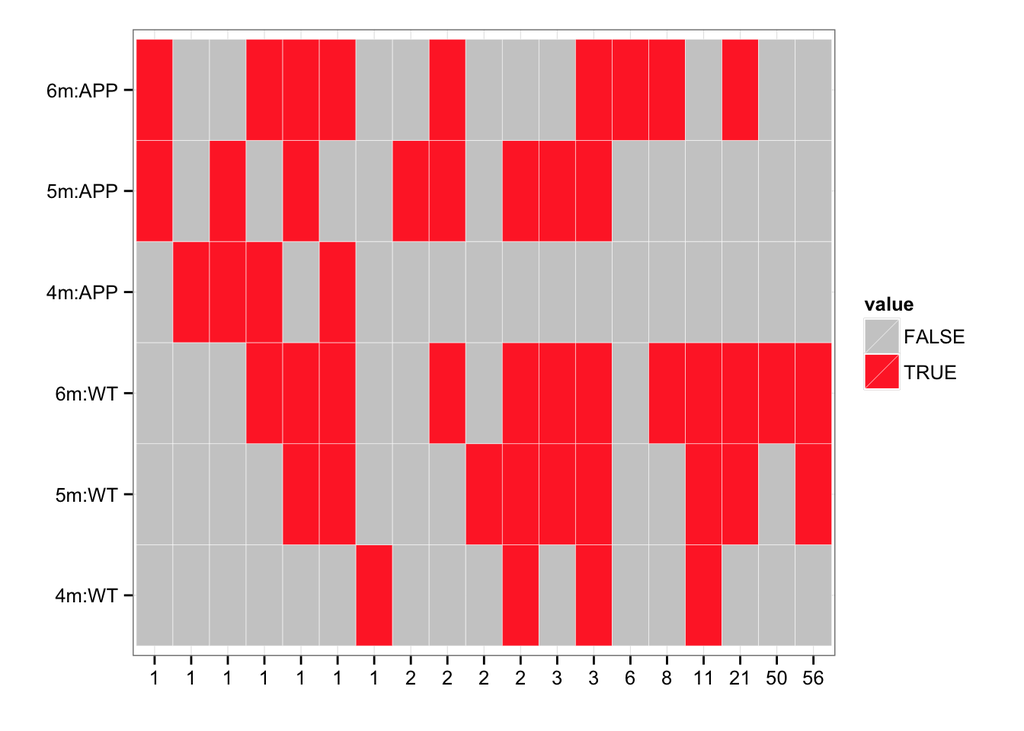

```r
tile.dt <- NULL
for (i in 1:length(profile.Id))
  tile.dt <- rbind(tile.dt, as.logical(unlist(strsplit(profile.Id[i], "-"))))
tile.dt <- data.frame(value = c(tile.dt),
  profile = factor(rep(profile.Id, ncol(tile.dt)), levels = profile.Id),
  group = factor(rep(colnames(profile), each = nrow(tile.dt)), levels = colnames(profile)))

ggplot(tile.dt, aes(x = group, y = profile, fill = value)) + geom_tile(colour = "white") +
  theme_bw() + xlab("") + ylab("") + coord_flip() +
# scale_x_discrete(labels = c("2m:APP", "4m:APP", "5m:APP", "6m:APP")) +
  scale_x_discrete(labels = c("4m:WT", "5m:WT", "6m:WT", "4m:APP", "5m:APP", "6m:APP")) +
  scale_y_discrete(labels = profile.table) +
  scale_fill_manual(values = c("grey80", "firebrick1"))
```